# EDA on Production Data

# Read the data

```r
dataPrep_rdd <-
  read.csv(file = '../data/dataPrep_production_rdd.csv') %>%
  mutate(var = 'rdd', Wine_mhl = as.double(Wine_mhl) )

dataPrep_rvv <-
  read.csv(file = '../data/dataPrep_production_rvv.csv') %>%
  mutate(var = 'rvv',  DOY_Fs = 0, Wine_mhl = as.double(Wine_mhl))

df_prd <- rbind(dataPrep_rdd, dataPrep_rvv)


df_prd
```

| Year | Wine_mhl | DOY_BB | DOY_Fl | DOY_sM | DOY_Fs | DOY_Hv | var |
| --- | --- | --- | --- | --- | --- | --- | --- |
| 1933 | 753.4 | 96 | 133 | 176 | 141 | 248 | rdd |
| 1934 | 835.6 | 107 | 146 | 184 | 157 | 265 | rdd |
| 1935 | 656.7 | 99 | 152 | 193 | 166 | 275 | rdd |
| 1936 | 523.3 | 72 | 130 | 187 | 146 | 267 | rdd |
| 1937 | 870.0 | 86 | 132 | 177 | 148 | 250 | rdd |
| 1938 | 992.6 | 88 | 130 | 176 | 144 | 255 | rdd |
| 1939 | 724.5 | 77 | 144 | 189 | 153 | 273 | rdd |
| 1940 | 520.9 | 77 | 128 | 176 | 142 | 254 | rdd |
| 1941 | 663.8 | 87 | 141 | 186 | 159 | 268 | rdd |
| 1942 | 718.4 | 93 | 140 | 181 | 153 | 262 | rdd |

[output cut: 162 more lines]

```r
ts.rdd <- ts( dataPrep_rdd$Wine_mhl, start = c(min(dataPrep_rdd$Year) ), frequency = 1)
ts.rvv <- ts( dataPrep_rvv$Wine_mhl, start = c(min(dataPrep_rvv$Year) ), frequency = 1)

str(ts.rdd)
```

```
##  Time-Series [1:90] from 1933 to 2022: 753 836 657 523 870 ...
```

```r
str(ts.rvv)
```

```
##  Time-Series [1:82] from 1941 to 2022: 1295 1061 3008 3070 2205 ...
```

# EDA Production Data

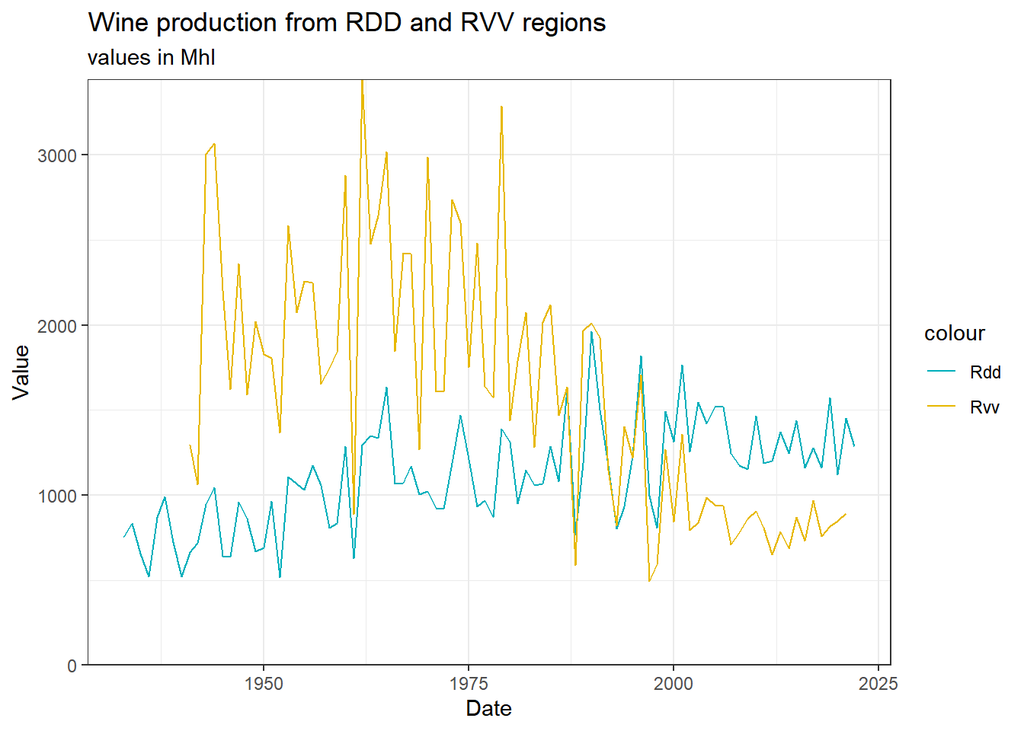

```r
# convert the time series to data frames with a date column
df1 <- data.frame(Date = time(ts.rdd), Value1 = ts.rdd)
df2 <- data.frame(Date = time(ts.rvv), Value2 = ts.rvv)

# left join the two data frames based on the Date column
df_joined <- left_join(df1, df2, by = "Date")


# plot wine production fro the two regions
ggplot(df_joined, aes(x = Date)) +
  geom_line(aes(y = Value1, color = "Rdd")) +
  geom_line(aes(y = Value2, color = "Rvv")) +
  labs(title = "Wine production from RDD and RVV regions", x = "Date", y = "Value", subtitle = 'values in Mhl') +
  scale_color_manual(values = c("Rdd" = "#00AFBB", "Rvv" = "#E7B800")) +
  scale_y_continuous(expand = c(0, 0), limits = c(0,NA)) +
  theme_bw()
```

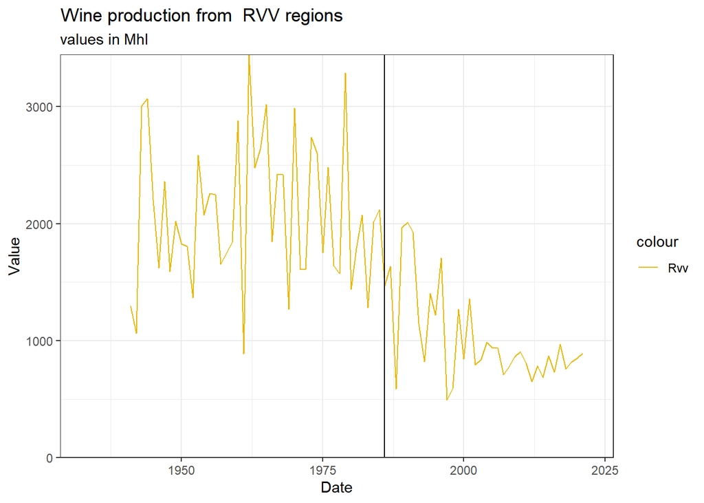

```r
# plot wine production RVV with regulation year
ggplot(df_joined, aes(x = Date)) +
  geom_line(aes(y = Value2, color = "Rvv")) +
  labs(title = "Wine production from  RVV regions", x = "Date", y = "Value", subtitle = 'values in Mhl') +
  scale_color_manual(values = c( "Rvv" = "#E7B800")) +
  scale_y_continuous(expand = c(0, 0), limits = c(0,NA)) +
  geom_vline(xintercept = 1986) +
  theme_bw()
```

```r
# create plotly line chart


df_joined %>%
  plot_ly( x = ~Date, y = ~Value1, type = "scatter", mode = "lines", name = "Rdd") %>%
  add_trace(y = ~Value2, name = "Rvv") %>%
  layout(title = "Wine production from RDD and RVV regions",
         xaxis = list(title = "Date"),
         yaxis = list(title = "Production Mhl", range = c(0, max(df_joined[,2:3], na.rm = TRUE))))
```

[interactive chart not shown]

### Rdd region

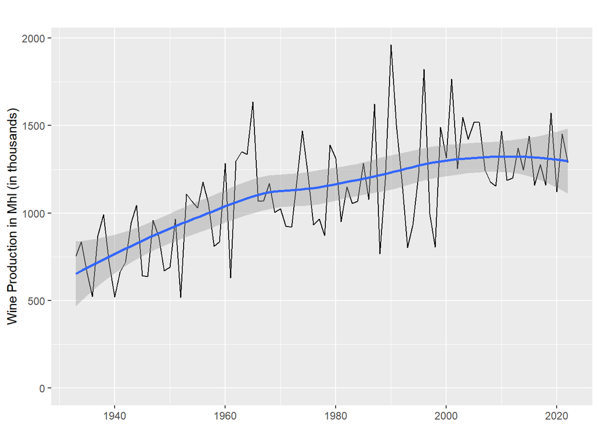

```r
## rdd plots  ----------------------

#autoplot(ts.rdd, main = 'Wine production for RDD region in Mhl')

autoplot(ts.rdd)+
  geom_smooth() +
   expand_limits(y = 0) +
  labs('Wine production for RDD region in Mh',
       y = "Wine Production in Mhl (in thousands)",
       x = NULL)
```

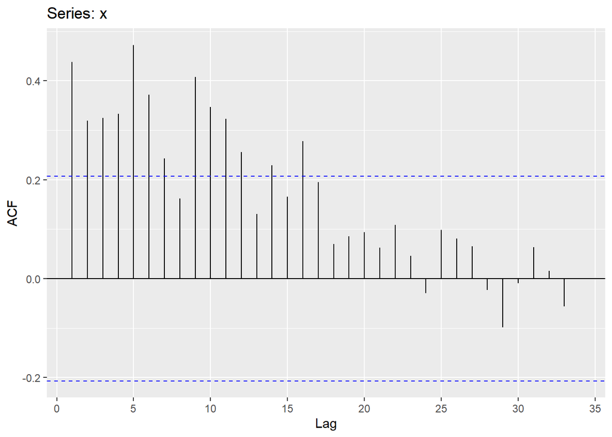

```r
x <- ts.rdd

# # lag plot of the series
# gglagplot(x)

# ACF plot of the series
ggAcf(x, lag.max = 34)
```

### RVV

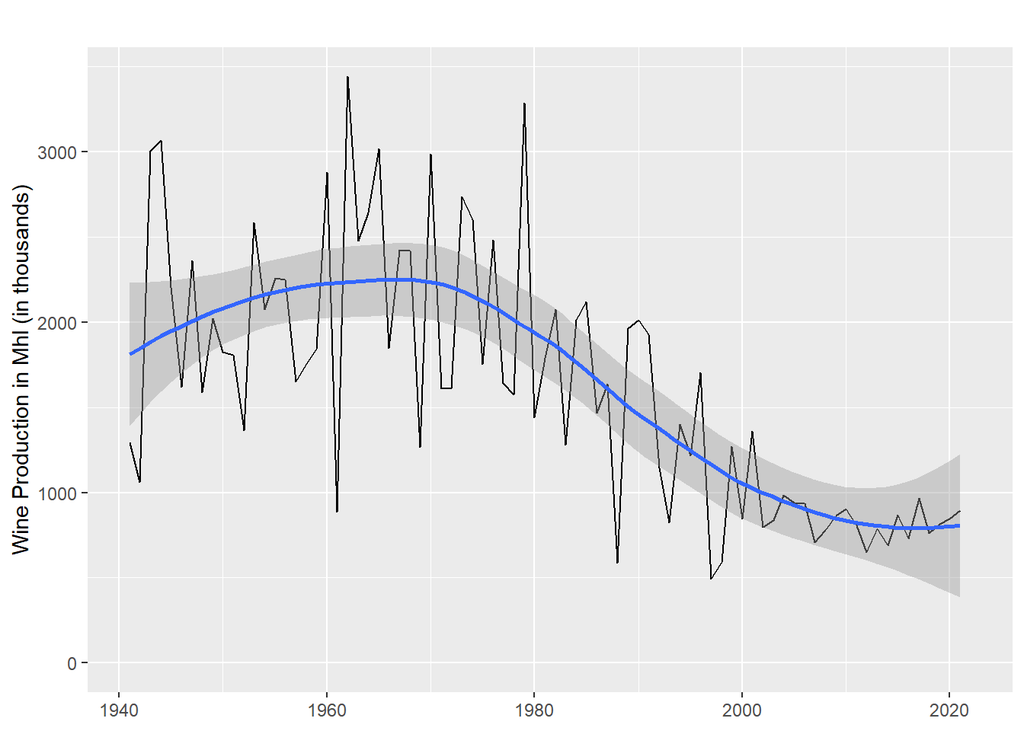

```r
autoplot(ts.rvv)+
  geom_smooth() +
  expand_limits(y = 0) +
  labs('Wine production for RVV region in Mh',
       y = "Wine Production in Mhl (in thousands)",
       x = NULL)
```

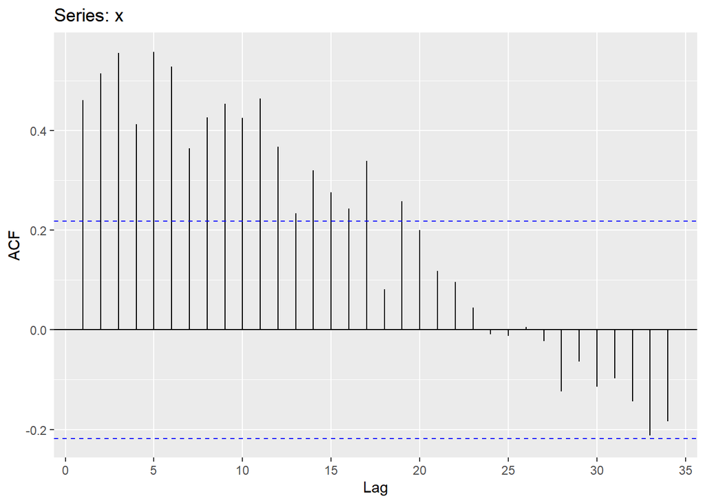

```r
x <- ts.rvv

# # lag plot of the series
# gglagplot(x)

# ACF plot of the series
ggAcf(x, lag.max = 34)
```

## stationary

To check if a time series is stationary, we can perform a statistical test, such as the **Augmented Dickey-Fuller (ADF)** test or the **Kwiatkowski-Phillips-Schmidt-Shin (KPSS)** test.

The ADF test checks for the presence of a unit root in the time series. The ADF test is based on the null hypothesis that the time series has a unit root (i.e., it is non-stationary), and the alternative hypothesis that the time series is stationary. **If the p-value is less than the significance level (usually 0.05), then we can reject the null hypothesis** of a unit root and conclude that the **time series is stationary**

The KPSS test checks for **trend stationarity** (i.e., the absence of a trend) and **level stationarity** (i.e., the absence of a systematic difference between the mean and variance of the time series).

### Tests for RDD

```r
# Perform the ADF test
adf.test(ts.rdd)
```

```
##
##  Augmented Dickey-Fuller Test
##
## data:  ts.rdd
## Dickey-Fuller = -3.2485, Lag order = 4, p-value = 0.0849
## alternative hypothesis: stationary
```

```r
# Perform the KPSS test
kpss.test(ts.rdd, null = 'Trend')
```

```
##
##  KPSS Test for Trend Stationarity
##
## data:  ts.rdd
## KPSS Trend = 0.14496, Truncation lag parameter = 3, p-value = 0.05193
```

### Tests for RVV

```r
# Perform the ADF test
adf.test(na.exclude(ts.rvv))
```

```
##
##  Augmented Dickey-Fuller Test
##
## data:  na.exclude(ts.rvv)
## Dickey-Fuller = -2.1809, Lag order = 4, p-value = 0.5017
## alternative hypothesis: stationary
```

```r
# Perform the KPSS test
kpss.test(na.exclude(ts.rvv), null = 'Trend')
```

```
##
##  KPSS Test for Trend Stationarity
##
## data:  na.exclude(ts.rvv)
## KPSS Trend = 0.29441, Truncation lag parameter = 3, p-value = 0.01
```

# EDA

Check the days of Year for the several events

```r
# https://r-graph-gallery.com/density_mirror_ggplot2.html

df_prd %>% select(var,DOY_BB,DOY_Fl, DOY_sM,DOY_Hv) %>%
  gather(key = key, value = value,- var) %>%
  group_by(var, key) %>%
  summarise(#min = min(value),
            #max = max(value),
            median = median(value),.groups = 'drop') %>%
  spread(key = var,value = median) %>%
  rename(median_rdd = rdd,
         median_rvv = rvv) %>%
  kable() %>% kableExtra::kable_minimal()
```

| key | median_rdd | median_rvv |
| --- | --- | --- |
| DOY_BB | 87.5 | 88.5 |
| DOY_Fl | 135.0 | 154.0 |
| DOY_Hv | 257.0 | 267.5 |
| DOY_sM | 179.0 | 225.5 |

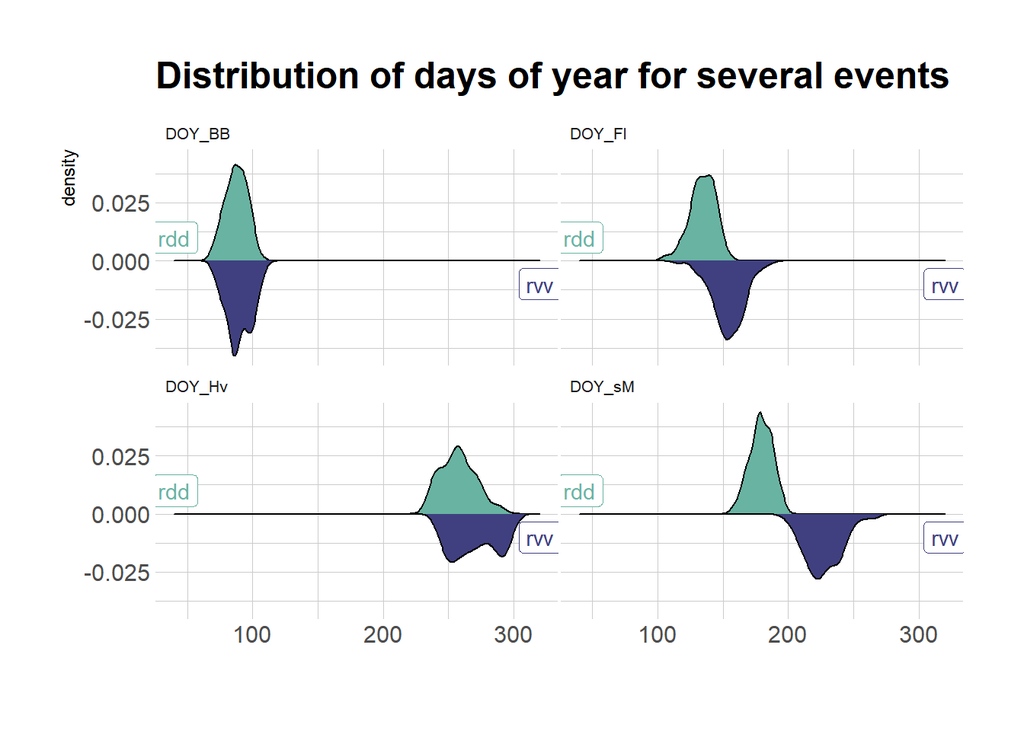

```r
  #add_header_above(c(" ", "Hello" = 2, "World" = 2))


df_prd %>%
    select(- Wine_mhl, - DOY_Fs) %>%
    rename(Region = var) %>%
   # mutate(index = row_number()) %>%
    gather(key = variable, value = value, -Region, -Year) %>%
    spread(key = Region,value = value) %>%
    ggplot() +

    # Top
    geom_density( aes(x = rdd, y = ..density..), fill="#69b3a2" ) +
    geom_label( aes(x=40, y=0.01, label="rdd"), color="#69b3a2") +

    # Bottom
    geom_density( aes(x = rvv, y = -..density..), fill= "#404080") +
    geom_label( aes(x=320, y=-0.01, label="rvv"), color="#404080") +

    theme_ipsum() +
    theme(
      panel.spacing = unit(0.1, "lines"),
      strip.text.x = element_text(size = 8)
    ) +
    xlab("") +
    labs(title = 'Distribution of days of year for several events') +
    facet_wrap(~variable)
```

```r
## RDD variables  ----------------------

# df_prd %>%
#  # filter(var == 'rdd' ) %>%
#   select(-Year, -Wine_mhl) %>%
#   gather(key="region", value="value") %>%
#   mutate(value = round(as.numeric(value),0)) %>%
#   mutate_all(~ifelse(is.na(.), 0, .)) %>%
#
#   mutate(region = fct_reorder(region, value)) %>%
#   ggplot( aes(color=region, fill=region)) +
#
#   ## histogram  ----------------------
#
#   # geom_histogram(alpha=0.6, binwidth = 5) +
#
#   ## densitys  ----------------------
#
#   geom_density( aes(x = value, y = ..density..) ) +
#
#     scale_fill_viridis(discrete=TRUE) +
#     scale_color_viridis(discrete=TRUE) +
#
#
#     theme_ipsum() +
#     theme(
#       legend.position="none",
#       panel.spacing = unit(0.1, "lines"),
#       strip.text.x = element_text(size = 8)
#     ) +
#     xlab("") +
#     ylab("Assigned Probability (%)") +
#     labs(title = 'RDD days of the year distributions for events') +
#     facet_wrap(~region)
```

## Day of the Year for the Bud Break – DOY_BB

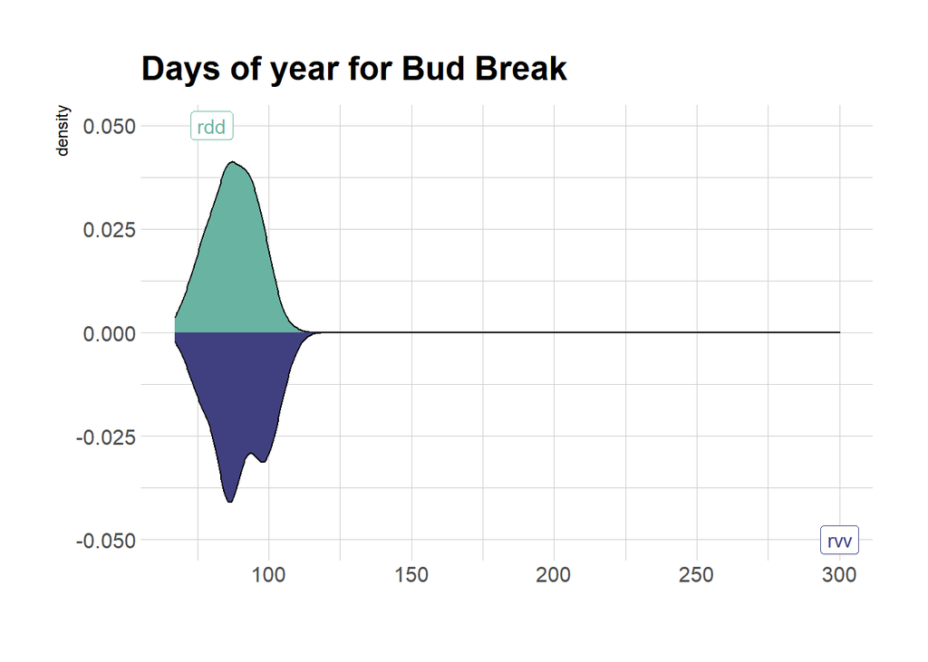

```r
plot_densitys(df_prd = df_prd, x = 'DOY_BB', x_label =  'Bud Break')
```

## Day of the Year for Flowering – DOY_Fl

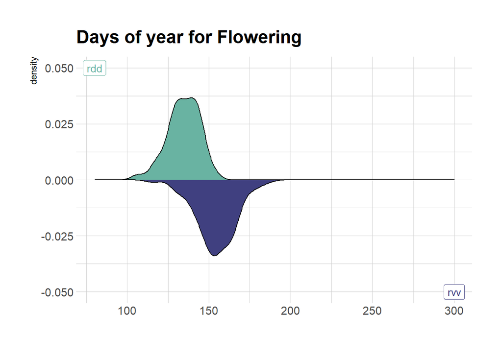

```r
plot_densitys(df_prd = df_prd, x = 'DOY_Fl', x_label =  'Flowering')
```

## Day of the Year for Start of the maturity – DOY_sM

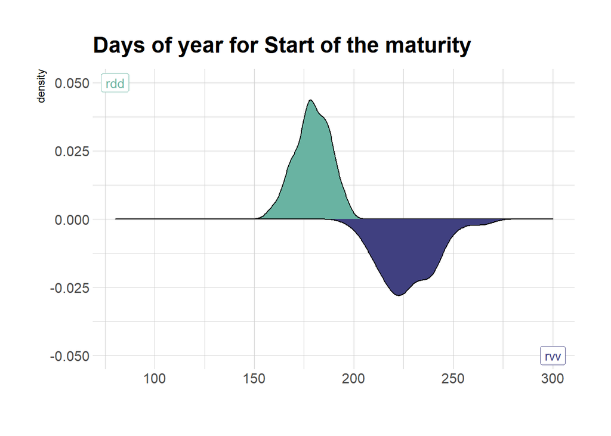

```r
plot_densitys(df_prd = df_prd, x = 'DOY_sM', x_label =  'Start of the maturity')
```

Data for the RVV is not available for Fruit Set

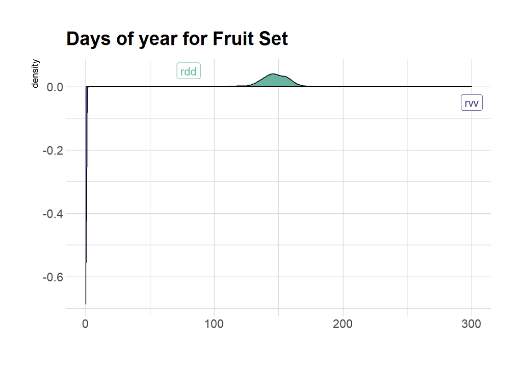

```r
plot_densitys(df_prd , x = 'DOY_Fs', x_label =  'Fruit Set')
```

## Day of the Year for the Harvest – DOY_Hv

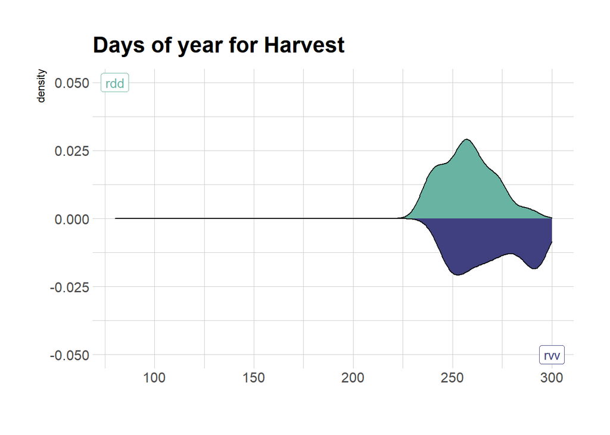

```r
plot_densitys(df_prd , x = 'DOY_Hv', x_label =  'Harvest')
```